# cm008 Exercises: Fix the Plots

In this worksheet, we’ll be looking at some erroneous plots and fixing them.

I think you might not have these two packages installed:

```
install.packages("ggridges")
install.packages("scales")
```

```r
library(tidyverse)
library(gapminder)
library(ggridges)
library(scales)
```

## Exercise 1: Overlapping Points

After fixing the error, fix the overlapping problem in the following plot (attribution: [“R for data science”](https://r4ds.had.co.nz/data-visualisation.html)).

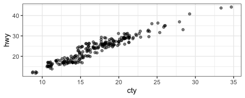

```r
ggplot(mpg, aes(cty, hwy)) +
  geom_jitter(alpha = 0.5) +
  theme_bw()
```

## Exercise 2: Line for each Country

Fix this plot so that it shows life expectancy over time *for each country*. Notice that `ggplot2` ignores the grouping of a tibble!

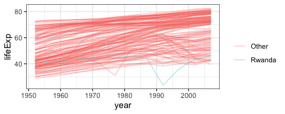

```r
gapminder %>%
  #group_by(country) %>%
  ggplot(aes(year, lifeExp, group = country, colour = country == "Rwanda")) + #color only Rwanda
  geom_line(alpha = 1/3) +
  scale_color_discrete("", labels = c("Other", "Rwanda"))+ #Change the legend labels and remove the legend title
  theme_bw()
```

## Exercise 3: More gdpPercap vs lifeExp

### 3(a) Facets

- Change the x-axis text to be in “comma format” with `scales::comma_format()`.
- Separate each continent into sub-panels.

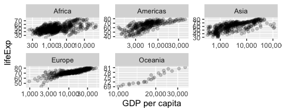

```r
ggplot(gapminder, aes(gdpPercap, lifeExp)) +
  geom_point(alpha = 0.2) +
  scale_x_log10("GDP per capita", labels = scales::comma_format())+
  facet_wrap(~continent, scales = "free" ) #scales = free gives each panel its own x and y axis but can no longer compare between plots because the scales are different. Can also do "free_y"
```

### 3(b) Bubble Plot

- Put the plots in one row, and free up the axes.
- Make a bubble plot by making the size of the points proportional to population.
  - Try adding a `scale_size_area()` layer too (could also try `scale_radius()`).
- Use `shape=21` to distinguish between `fill` (interior) and `colour` (exterior).

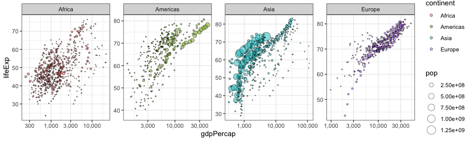

```r
gapminder %>%
  filter(continent != "Oceania") %>% #"!=" filters out Oceania
  ggplot(aes(gdpPercap, lifeExp, size = pop, fill = continent)) +
  facet_wrap(~ continent, nrow = 1, scales= "free") +
  geom_point(alpha = 0.5, shape = 21) +
  scale_size_area()+
  scale_x_log10(labels = scales::comma_format())+
  theme_bw()
```

A list of shapes can be found [at the bottom of the `scale_shape` documentation](https://ggplot2.tidyverse.org/reference/scale_shape.html).

### 3(c) Size “not working”

Instead of alpha transparency, suppose you’re wanting to fix the overplotting issue by plotting small points. Why is this not working? Fix it.

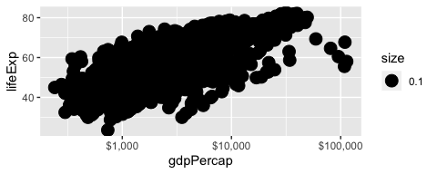

```r
ggplot(gapminder) +
  geom_point(aes(gdpPercap, lifeExp, size = 0.1)) +
  scale_x_log10(labels = scales::dollar_format())
```

## Exercise 4: Walking caribou

The following mock data set marks the (x,y) position of a caribou at four time points.

- Fix the plot below so that it shows the path of the caribou.
- Add an arrow with `arrow = arrow()`.
- Add the `time` label with `geom_text()`.

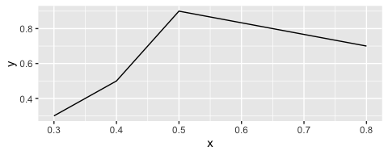

```r
tribble(
  ~time, ~x, ~y,
  1, 0.3, 0.3,
  2, 0.8, 0.7,
  3, 0.5, 0.9,
  4, 0.4, 0.5
) %>%
  ggplot(aes(x, y)) +
  geom_line()
```

### 5(a) Unhiding the data

Fix the plot so that you can actually see the data points. Be sure to solve the problem of overlapping text, without rotating the text.

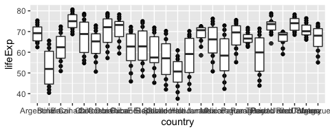

```r
gapminder %>%
  filter(continent == "Americas") %>%
  ggplot(aes(country, lifeExp)) +
  geom_point() +
  geom_boxplot()
```

### 5(b) Ridgeplots

We’re starting with the same plot as above, but instead of the points + boxplot, try a ridge plot instead using `ggridges::geom_density_ridges()`, and adjust the `bandwidth`.

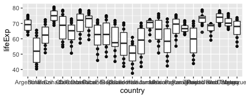

```r
gapminder %>%
  filter(continent == "Americas") %>%
  ggplot(aes(country, lifeExp)) +
  geom_point() +
  geom_boxplot()
```

## Exercise 6: Bar plot madness

### 6(a) Colour and stacking madness

- Change the following plot so that it shows *proportion* on the y-axis, not count.
- Change the x-axis so that it doesn’t appear to be continuous.
- Put the bars for transmission side-by-side with their own colour.
- Capitalize the legend title.

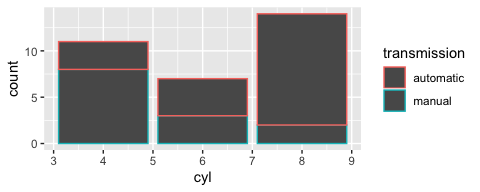

```r
mtcars %>%
  mutate(transmission = if_else(am == 0, "automatic", "manual")) %>%
  ggplot(aes(cyl)) +
  geom_bar(aes(colour = transmission))
```

### 6(b) Bar heights already calculated

Here’s the number of people having a certain hair colour from a sample of 592 people:

```r
(hair <- as_tibble(HairEyeColor) %>%
  count(Hair, wt = n))
```

```
## # A tibble: 4 x 2
##   Hair      n
##   <chr> <dbl>
## 1 Black   108
## 2 Blond   127
## 3 Brown   286
## 4 Red      71
```

Fix the following bar plot so that it shows these counts.

```r
ggplot(hair, aes(Hair, n)) +
  geom_bar()
```

```
## Error: stat_count() must not be used with a y aesthetic.
```

## Exercise 7: Tiling

Here’s the number of people having a certain hair and eye colour from a sample of 592 people:

```r
(hair_eye <- as_tibble(HairEyeColor) %>%
  count(Hair, Eye, wt = n))
```

```
## # A tibble: 16 x 3
##    Hair  Eye       n
##    <chr> <chr> <dbl>
##  1 Black Blue     20
##  2 Black Brown    68
##  3 Black Green     5
##  4 Black Hazel    15
##  5 Blond Blue     94
##  6 Blond Brown     7
##  7 Blond Green    16
##  8 Blond Hazel    10
##  9 Brown Blue     84
## 10 Brown Brown   119
## 11 Brown Green    29
## 12 Brown Hazel    54
## 13 Red   Blue     17
## 14 Red   Brown    26
## 15 Red   Green    14
## 16 Red   Hazel    14
```

Fix the following plot so that it shows a filled-in square for each combination.

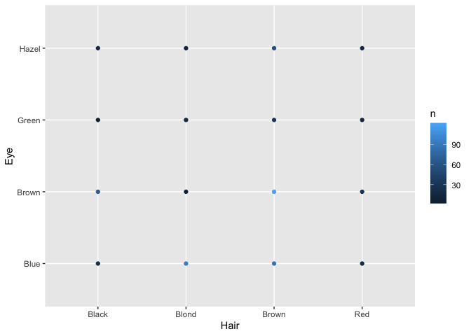

```r
ggplot(hair_eye, aes(Hair, Eye)) +
  geom_point(aes(colour = n))
```

By the way, `geom_count()` is like `geom_bar()`: it counts the number of overlapping points.

## Additional take-home practice

If you’d like some practice, give these exercises a try

**Exercise 1**: Make a plot of `year` (x) vs `lifeExp` (y), with points coloured by continent. Then, to that same plot, fit a straight regression line to each continent, without the error bars. If you can, try piping the data frame into the `ggplot()` function.

**Exercise 2**: Repeat Exercise 1, but switch the *regression line* and *geom_point* layers. How is this plot different from that of Exercise 1?

**Exercise 3**: Omit the `geom_point()` layer from either of the above two plots (it doesn’t matter which). Does the line still show up, even though the data aren’t shown? Why or why not?

**Exercise 4**: Make a plot of `year` (x) vs `lifeExp` (y), facetted by continent. Then, fit a smoother through the data for each continent, without the error bars. Choose a span that you feel is appropriate.

**Exercise 5**: Plot the population over time (year) using lines, so that each country has its own line. Colour by `gdpPercap`. Add alpha transparency to your liking.

**Exercise 6**: Add points to the plot in Exercise 5.